# Working with APIs in R

Author

Nathaniel Grimes

Published

March 13, 2025

```r
# install.packages("devtools")
#
# # Run once devtools is successfully installed
# devtools::install_github("cfree14/wcfish", force=T)

library(sf)
library(rnaturalearth)
library(tidyverse)
library(jsonlite)
library(here)
library(wcfish)
library(rerddap)
```

# API used in Shiny App

[Tyler’s Phish API](https://tylerclavelle.shinyapps.io/thePhactory/)

see https://docs.phish.net/examples for API documentation.

Also, check out https://shiny.posit.co/r/articles/share/shinyapps/ to deploy your Shiny app online for other users. Free account is limited to 25 hours of user time per month, and better than nothing!

# Accessing IUCN API

- first: add API key to .Renviron and why do it this way?
  - in console: `usethis::edit_r_environ()`
  - add line with a useful recognizable name and your API key
  - e.g., `IUCN_KEY=12345678`
- second: accessing API key
  - now in your code, you can access this key with `api_key <- Sys.getenv('IUCN_KEY')`
- if no personal API key yet, use the API demo one:
  - 9bb4facb6d23f48efbf424bb05c0c1ef1cf6f468393bc745d42179ac4aca5fee

```r
api_key <- Sys.getenv('IUCN_KEY')

api_key <- '9bb4facb6d23f48efbf424bb05c0c1ef1cf6f468393bc745d42179ac4aca5fee'
```

## Get the IUCN Redlist version: look up the endpoint on the reference!

The documentation for the IUCN RedList REST API is very thorough, and will be useful throughout this lab to identify various endpoints for different types of queries we want to perform: https://apiv3.iucnredlist.org/api/v3/docs

Version endpoint: `/api/v3/version` (no token needed!)

```r
### append the endpoint to the domain name:
domain_name <- 'http://apiv3.iucnredlist.org'
version_end <- 'api/v3/version'

version_url <- file.path(domain_name, version_end)
api_version <- jsonlite::fromJSON(version_url)
api_version$version
```

```
[1] "2024-2"
```

## Get a count of how many species have been assessed

Here we need to use the token to access this endpoint.

spp count endpoint: `/api/v3/speciescount?token='YOUR TOKEN'`

```r
count_stem <- 'api/v3/speciescount?token=%s'
  ### a format string for sprintf - %s means replace this with character string var;
  ### lots of numeric formats supported,
  ### e.g., sprintf('%f', pi) vs sprintf('%.3f', pi)
count_end <- sprintf(count_stem, api_key)
count_url <- file.path(domain_name, count_end)

spp_count <- jsonlite::fromJSON(count_url)
spp_count$count
```

```
[1] "169542"
```

## Get a page of results

Now we can also add parameter values to the endpoint.

page endpoint: `/api/v3/species/page/:page_number?token='YOUR TOKEN'`

```r
page_stem <- 'api/v3/species/page/%s?token=%s'
page_end <- sprintf(page_stem, 1, api_key) ### multiple variables into format string
page_url <- file.path(domain_name, page_end)

spp_page1 <- fromJSON(page_url)
```

Convert the extinction risk from the `spp_page1` object to an ordered factor going from Least Concerned to Extinct. Filter out observations that have `na` in the category column.

Plot the result as a bar graph to see the number of species in each designation.

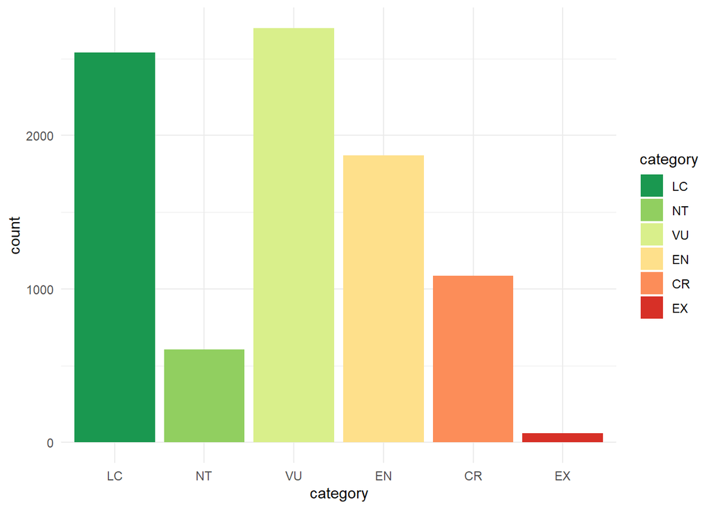

```r
### convert extinction risk into factor and plot counts
spp_df <- spp_page1$result %>%
  mutate(category = factor(category, levels = c('LC', 'NT', 'VU', 'EN', 'CR', 'EX'))) %>%
  filter(!is.na(category))

ggplot(spp_df) +
  geom_bar(aes(x = category, fill = category)) +
  scale_fill_brewer(palette = 'RdYlGn', direction = -1) +
  theme_minimal()
```

## Get current and historic assessment info for a species

historic assessments endpoint: `/api/v3/species/history/name/:name?token='YOUR TOKEN'`

Note, spaces won’t work in a URL - need to replace them with `%20`

```r
hist_stem <- 'api/v3/species/history/name/%s?token=%s'
spp <- 'Dermochelys%20coriacea'
hist_end <- sprintf(hist_stem, spp, api_key)
hist_url <- file.path(domain_name, hist_end)

spp_hist <- fromJSON(hist_url)
```

What year did Leatherback Turtles become Critically Endangered? What is their most recent status?

```r
spp_hist_df <- spp_hist$result

spp_hist_df
```

```
  year assess_year code              category
1 2013        2013   VU            Vulnerable
2 2000        2000   CR Critically Endangered
3 1996        1996   EN            Endangered
4 1994        1994    E            Endangered
5 1990        1990    E            Endangered
6 1988        1988    E            Endangered
7 1986        1986    E            Endangered
8 1982        1982    E            Endangered
```

## Pull threats and narrative, and extract information on gear types

Threats: `/api/v3/threats/species/name/:name?token='YOUR TOKEN'` Narratives: `/api/v3/species/narrative/:name?token='YOUR TOKEN'`

```r
threats_stem <- 'api/v3/threats/species/name/%s?token=%s'
thr_url <- file.path(domain_name, sprintf(threats_stem, spp, api_key))
spp_thr <- fromJSON(thr_url)$result

narratives_stem <- 'api/v3/species/narrative/%s?token=%s'
narr_url <- file.path(domain_name, sprintf(narratives_stem, spp, api_key))
spp_narr <- fromJSON(narr_url)$result

spp_narr$threats
```

```
[1] "<p>Threats to Leatherbacks vary in time and space, and in relative impact to populations. Threat categories affecting marine turtles, including Leatherbacks, were described by Wallace <em>et al</em>. (2011) as:</p>  <p>1) Fisheries bycatch: incidental capture of marine turtles in fishing gear t…
```

Note that the IUCN Red List site literally just calls its own API to build each page when you type in a species name!

# ERDDAP

NOAA’s [ERDDAP (Environmental Research Division Data Access Program)](https://coastwatch.pfeg.noaa.gov/erddap/index.html) site is home to thousands of datasets on environmental, biogeochemical, and ecological quantities, from satellites/remote sensing and in-situ sensors etc. These datasets can be searched through their website, but can also be accessed programmatically.

There are functions in the `rerrdap` package to help you look up datasets. I think it’s best to look directly at the search results on the website to find which datasets meet your needs, because it can be hard to see the complete structure of the datasets from the package. But, once you know what you want, you can use the package to access the data.

[Read the vignette on the package](https://cran.r-project.org/web/packages/rerddap/vignettes/Using_rerddap.html). They provide far more detail and useful suggestions to make sure you don’t break your computer.

Go to the website to explore. We will also see how the results compare with the function search.

```r
temp_search<-ed_search(query="Monthly SST")
```

Let’s start with a dataset of sea surface temperature data off the coast of California. We can use the `rerddap::info` function to look up the dataset ID, and then use the `rerddap::griddap` function to access the data.

```r
file_id<-rerddap::info(datasetid = "NOAA_DHW_monthly",
                       url = "https://coastwatch.pfeg.noaa.gov/erddap/")

start="2024-01-01"

end="2024-12-31"

sst<-griddap(datasetx=file_id,
             time=c(start,end),
             latitude=c(30,42),
             longitude=c(-115,-130),
             stride=2)$data %>%
  rename(t=time,temp=sea_surface_temperature)
```

Filter out the data for just one time unit (e.g. one month). Make a map of the data using `geom_tiles()`. Why can I not use `geom_sf()`?

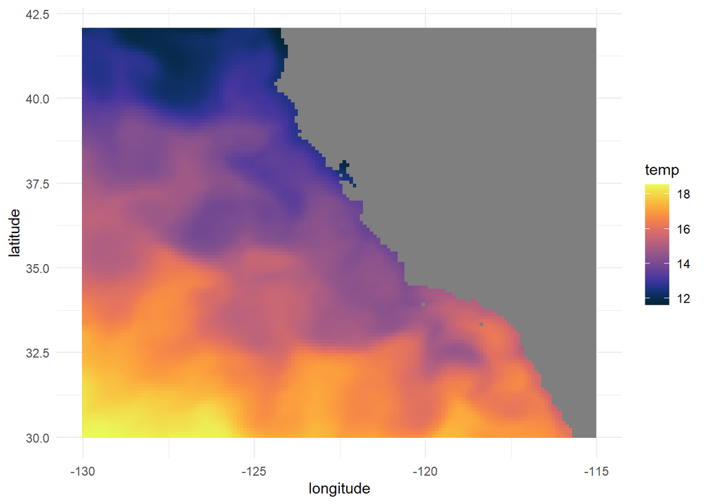

```r
sst |>
  filter(t==unique(t)[1]) |>
ggplot() +
  geom_tile(aes(x=longitude,y=latitude,fill=temp)) +
  scale_fill_gradientn(colors=pals::ocean.thermal(20),guide='colorbar')+
  theme_minimal()
```

Bring in the state boundaries from the `rnaturalearth` package.

Layer each `sf` onto the map of sea surface temperatures

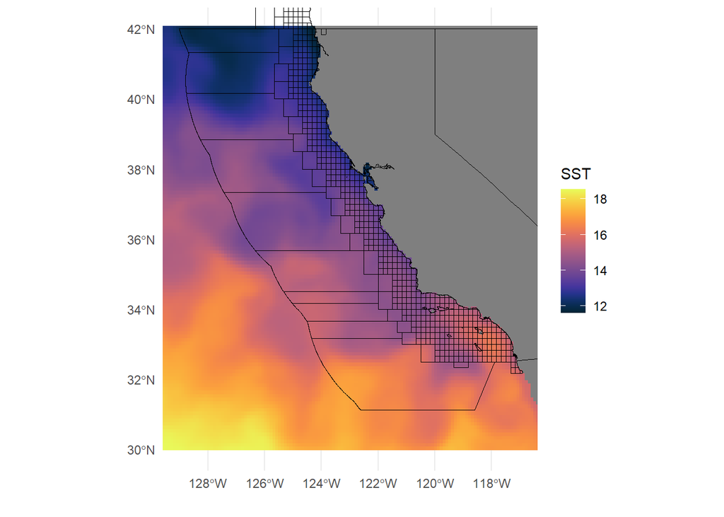

```r
state<-ne_states(country='United States of America')

state_sf<-st_as_sf(state) %>%
  filter(name %in% c('California','Nevada'))

#get rid of all the extra junk
state_sf<-state_sf[,c(9,84)]

sst |>
  filter(t==unique(t)[1]) |>
ggplot() +
  geom_tile(aes(x=longitude,y=latitude,fill=temp)) +
  geom_sf(data=wcfish::blocks,fill=NA,color='black',size=2)+
  geom_sf(data=state_sf,fill=NA,color='black')+
  coord_sf(xlim = c(-129,-117),ylim=c(30,42))+
  scale_fill_gradientn(colors=pals::ocean.thermal(20),guide='colorbar')+
  theme_minimal()+
  labs(y='',x='',fill='SST')
```

Now you have access to thousands of environmental datasets. Combine these with your complete data wrangling skills to create incredible datasets to conduct powerful analyses in your future work. Good Luck!